# Comparación de modelos[^1]

# Muchos Modelos- Clase 1

```r
library(modelr)
library(broom)
library(dplyr)
library(tidyr)
library(ggplot2)
library(purrr)
```

## gapminder

Los datos de gapminder resumen el progreso de los países a lo largo del tiempo, mirando estadísticas como la esperanza de vida y el PBI. Los datos son de fácil acceso en R, gracias a Jenny Bryan, quien creó el paquete gapminder:

```r
#install.packages("gapminder")
library(gapminder)
gapminder
```

```
#> # A tibble: 1,704 x 6
#>    country     continent  year lifeExp      pop gdpPercap
#>    <fct>       <fct>     <int>   <dbl>    <int>     <dbl>
#>  1 Afghanistan Asia       1952    28.8  8425333      779.
#>  2 Afghanistan Asia       1957    30.3  9240934      821.
#>  3 Afghanistan Asia       1962    32.0 10267083      853.
#>  4 Afghanistan Asia       1967    34.0 11537966      836.
#>  5 Afghanistan Asia       1972    36.1 13079460      740.
#>  6 Afghanistan Asia       1977    38.4 14880372      786.
#>  7 Afghanistan Asia       1982    39.9 12881816      978.
#>  8 Afghanistan Asia       1987    40.8 13867957      852.
#>  9 Afghanistan Asia       1992    41.7 16317921      649.
#> 10 Afghanistan Asia       1997    41.8 22227415      635.
#> # ... with 1,694 more rows
```

En este estudio de caso, vamos a centrarnos solo en tres variables para responder a la pregunta

> “¿Cómo cambia la esperanza de vida (`lifeExp`) en el tiempo (`year`) para cada país (`country`)?”

Un buen lugar para comenzar es con una gráfico:

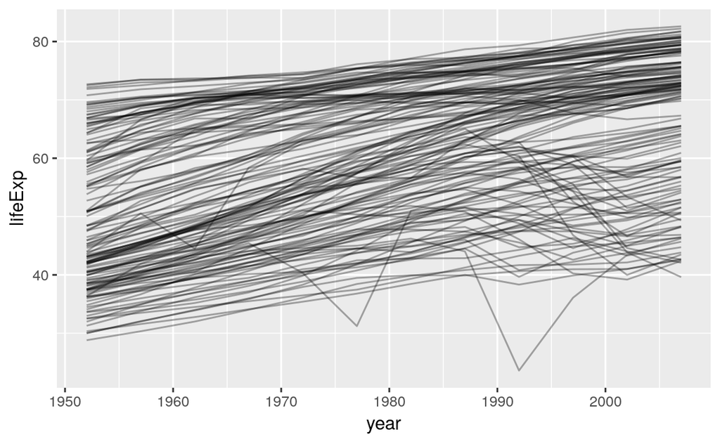

```r
gapminder %>%
  ggplot(aes(year, lifeExp, group = country)) +
    geom_line(alpha = 1/3)
```

Se puede ver que en general hay una tendencia a que suba la esperanza de vida en el tiempo, pero también algunos países parecen tener un comportamiento diferente.

Si quisieramos calcular el modelo lineal para alguno de estos países

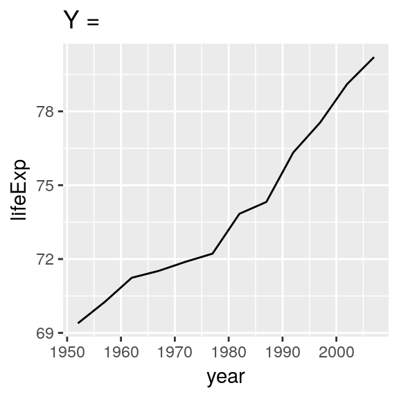

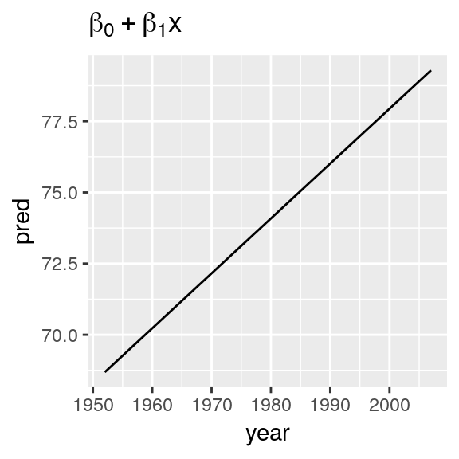

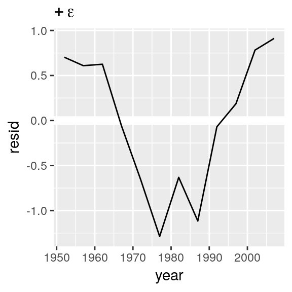

```r
nz <- filter(gapminder, country == "New Zealand")
nz %>%
  ggplot(aes(year, lifeExp)) +
  geom_line() +
  ggtitle("Y = ")

nz_mod <- lm(lifeExp ~ year, data = nz)
nz %>%
  add_predictions(nz_mod) %>%
  ggplot(aes(year, pred)) +
  geom_line() +
  ggtitle(expression(beta[0] + beta[1]*x))

nz %>%
  add_residuals(nz_mod) %>%
  ggplot(aes(year, resid)) +
  geom_hline(yintercept = 0, colour = "white", size = 3) +
  geom_line() +
  ggtitle(expression(+ epsilon))
```

Como hacemos para ajustar un modelo por país?

## Nested data

Si queremos replicar lo de arriba para todos los países, podríamos:

- copiar y pegar el código muchas veces 😡
- hacer un loop para que itere sobre el código 😞
- crear una función que haga el loop y nos devuelva las cosas de forma prolija 😒
- usar un dataframe con `nested` data y `map()` 😃

Ahora, en lugar de repetir una acción para cada variable, queremos repetir una acción para cada país, un subconjunto de filas. Para hacer eso, necesitamos el **nested dataframe**.

```r
by_country <- gapminder %>%
  group_by(country, continent) %>%
  nest()

by_country
```

```
#> # A tibble: 142 x 3
#>    country     continent data
#>    <fct>       <fct>     <list>
#>  1 Afghanistan Asia      <tibble [12 × 4]>
#>  2 Albania     Europe    <tibble [12 × 4]>
#>  3 Algeria     Africa    <tibble [12 × 4]>
#>  4 Angola      Africa    <tibble [12 × 4]>
#>  5 Argentina   Americas  <tibble [12 × 4]>
#>  6 Australia   Oceania   <tibble [12 × 4]>
#>  7 Austria     Europe    <tibble [12 × 4]>
#>  8 Bahrain     Asia      <tibble [12 × 4]>
#>  9 Bangladesh  Asia      <tibble [12 × 4]>
#> 10 Belgium     Europe    <tibble [12 × 4]>
#> # ... with 132 more rows
```

Esto crea un dataframe que tiene una fila por grupo (por país) y una columna bastante inusual: `data` es una lista de dataframes

```r
by_country$data[[1]]
```

```
#> # A tibble: 12 x 4
#>     year lifeExp      pop gdpPercap
#>    <int>   <dbl>    <int>     <dbl>
#>  1  1952    28.8  8425333      779.
#>  2  1957    30.3  9240934      821.
#>  3  1962    32.0 10267083      853.
#>  4  1967    34.0 11537966      836.
#>  5  1972    36.1 13079460      740.
#>  6  1977    38.4 14880372      786.
#>  7  1982    39.9 12881816      978.
#>  8  1987    40.8 13867957      852.
#>  9  1992    41.7 16317921      649.
#> 10  1997    41.8 22227415      635.
#> 11  2002    42.1 25268405      727.
#> 12  2007    43.8 31889923      975.
```

Tengan en cuenta la diferencia entre DF agrupado estándar y un DF anidado:

- en un DF agrupado, cada fila es una observación
- en un DF anidado, cada fila es un grupo

Otra forma de pensar sobre un conjunto de datos anidados es que ahora tenemos una **metaobservación**: una fila que representa el curso de tiempo completo para un país, en lugar de un único punto en el tiempo.

## List-columns

Con este DF podemos utilizar la función para ajustar los modelos

```r
country_model <- function(df) {
  lm(lifeExp ~ year, data = df)
}
```

Queremos aplicarlo a cada uno de los dataframes anidados. Podemos usar `purrr::map()` para aplicar la función que definimos a cada elemento

```r
models <- map(by_country$data, country_model)
```

En lugar de crear un nuevo objeto en el entorno global, vamos a crear una nueva variable en el DF `by_country`. Ese es un trabajo para `dplyr :: mutate ()`:

```r
by_country <- by_country %>%
  mutate(model = map(data, country_model))
by_country
```

```
#> # A tibble: 142 x 4
#>    country     continent data              model
#>    <fct>       <fct>     <list>            <list>
#>  1 Afghanistan Asia      <tibble [12 × 4]> <S3: lm>
#>  2 Albania     Europe    <tibble [12 × 4]> <S3: lm>
#>  3 Algeria     Africa    <tibble [12 × 4]> <S3: lm>
#>  4 Angola      Africa    <tibble [12 × 4]> <S3: lm>
#>  5 Argentina   Americas  <tibble [12 × 4]> <S3: lm>
#>  6 Australia   Oceania   <tibble [12 × 4]> <S3: lm>
#>  7 Austria     Europe    <tibble [12 × 4]> <S3: lm>
#>  8 Bahrain     Asia      <tibble [12 × 4]> <S3: lm>
#>  9 Bangladesh  Asia      <tibble [12 × 4]> <S3: lm>
#> 10 Belgium     Europe    <tibble [12 × 4]> <S3: lm>
#> # ... with 132 more rows
```

Esto tiene una gran ventaja: debido a que todos los objetos relacionados se almacenan juntos, no es necesario que los mantengas sincronizados manualmente cuando los filtres o organices. La semántica del DF nos ayuda a tener todo organizado:

```r
by_country %>%
  filter(continent == "Europe")
```

```
#> # A tibble: 30 x 4
#>    country                continent data              model
#>    <fct>                  <fct>     <list>            <list>
#>  1 Albania                Europe    <tibble [12 × 4]> <S3: lm>
#>  2 Austria                Europe    <tibble [12 × 4]> <S3: lm>
#>  3 Belgium                Europe    <tibble [12 × 4]> <S3: lm>
#>  4 Bosnia and Herzegovina Europe    <tibble [12 × 4]> <S3: lm>
#>  5 Bulgaria               Europe    <tibble [12 × 4]> <S3: lm>
#>  6 Croatia                Europe    <tibble [12 × 4]> <S3: lm>
#>  7 Czech Republic         Europe    <tibble [12 × 4]> <S3: lm>
#>  8 Denmark                Europe    <tibble [12 × 4]> <S3: lm>
#>  9 Finland                Europe    <tibble [12 × 4]> <S3: lm>
#> 10 France                 Europe    <tibble [12 × 4]> <S3: lm>
#> # ... with 20 more rows
```

```r
by_country %>%
  arrange(continent, country)
```

```
#> # A tibble: 142 x 4
#>    country                  continent data              model
#>    <fct>                    <fct>     <list>            <list>
#>  1 Algeria                  Africa    <tibble [12 × 4]> <S3: lm>
#>  2 Angola                   Africa    <tibble [12 × 4]> <S3: lm>
#>  3 Benin                    Africa    <tibble [12 × 4]> <S3: lm>
#>  4 Botswana                 Africa    <tibble [12 × 4]> <S3: lm>
#>  5 Burkina Faso             Africa    <tibble [12 × 4]> <S3: lm>
#>  6 Burundi                  Africa    <tibble [12 × 4]> <S3: lm>
#>  7 Cameroon                 Africa    <tibble [12 × 4]> <S3: lm>
#>  8 Central African Republic Africa    <tibble [12 × 4]> <S3: lm>
#>  9 Chad                     Africa    <tibble [12 × 4]> <S3: lm>
#> 10 Comoros                  Africa    <tibble [12 × 4]> <S3: lm>
#> # ... with 132 more rows
```

Si la lista de DF y la lista de modelos eran objetos separados, cada vez que se reordena o filtra un elemento, necesitas volver a ordenar o filtrar todos los demás para mantenerlos sincronizados. Sino el código continuará funcionando, ¡pero **dará una respuesta incorrecta**!s

## Unnesting

Antes agregamos los residuos a un modelo, utilizando `add_residuals()`. Ahora necesitamos hacerlo sobre 142 modelos y 142 datasets: Necesitamos utilizar la función `map2()`

```r
by_country <- by_country %>%
  mutate(
    resids = map2(data, model, add_residuals)
  )
by_country
```

```
#> # A tibble: 142 x 5
#>    country     continent data              model    resids
#>    <fct>       <fct>     <list>            <list>   <list>
#>  1 Afghanistan Asia      <tibble [12 × 4]> <S3: lm> <tibble [12 × 5]>
#>  2 Albania     Europe    <tibble [12 × 4]> <S3: lm> <tibble [12 × 5]>
#>  3 Algeria     Africa    <tibble [12 × 4]> <S3: lm> <tibble [12 × 5]>
#>  4 Angola      Africa    <tibble [12 × 4]> <S3: lm> <tibble [12 × 5]>
#>  5 Argentina   Americas  <tibble [12 × 4]> <S3: lm> <tibble [12 × 5]>
#>  6 Australia   Oceania   <tibble [12 × 4]> <S3: lm> <tibble [12 × 5]>
#>  7 Austria     Europe    <tibble [12 × 4]> <S3: lm> <tibble [12 × 5]>
#>  8 Bahrain     Asia      <tibble [12 × 4]> <S3: lm> <tibble [12 × 5]>
#>  9 Bangladesh  Asia      <tibble [12 × 4]> <S3: lm> <tibble [12 × 5]>
#> 10 Belgium     Europe    <tibble [12 × 4]> <S3: lm> <tibble [12 × 5]>
#> # ... with 132 more rows
```

Para analizar los resultados, volvemos la lista de DF a un DF normal. Previamente utilizamos `nest()` para convertir un DF normal en un DF anidado, y ahora hacemos lo contrario con `unnest()`:

```r
resids <- unnest(by_country, resids)
resids
```

```
#> # A tibble: 1,704 x 7
#>    country     continent  year lifeExp      pop gdpPercap   resid
#>    <fct>       <fct>     <int>   <dbl>    <int>     <dbl>   <dbl>
#>  1 Afghanistan Asia       1952    28.8  8425333      779. -1.11
#>  2 Afghanistan Asia       1957    30.3  9240934      821. -0.952
#>  3 Afghanistan Asia       1962    32.0 10267083      853. -0.664
#>  4 Afghanistan Asia       1967    34.0 11537966      836. -0.0172
#>  5 Afghanistan Asia       1972    36.1 13079460      740.  0.674
#>  6 Afghanistan Asia       1977    38.4 14880372      786.  1.65
#>  7 Afghanistan Asia       1982    39.9 12881816      978.  1.69
#>  8 Afghanistan Asia       1987    40.8 13867957      852.  1.28
#>  9 Afghanistan Asia       1992    41.7 16317921      649.  0.754
#> 10 Afghanistan Asia       1997    41.8 22227415      635. -0.534
#> # ... with 1,694 more rows
```

Noten que unnest me deja las variables agrupadoras, junto con el DF.

Ahora sí podemos graficar los residuos

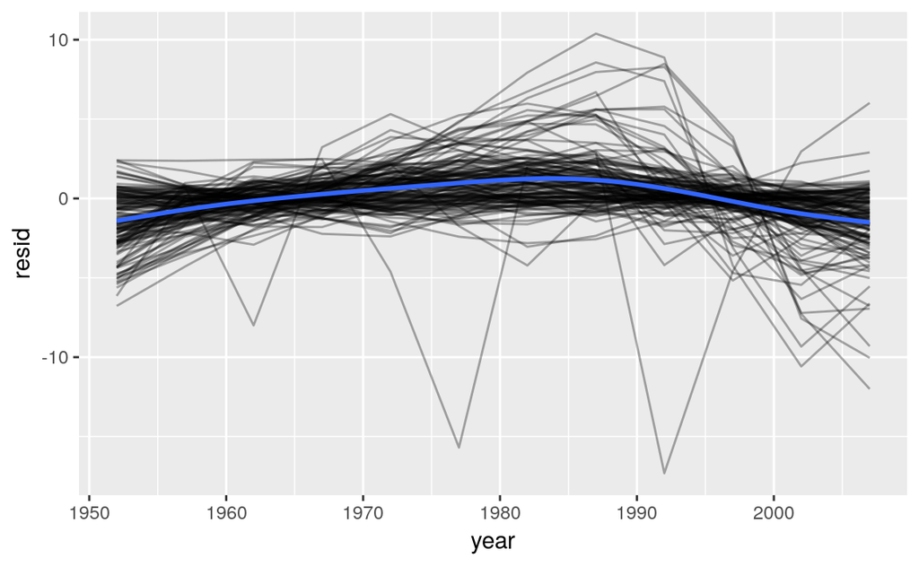

```r
resids %>%
  ggplot(aes(year, resid)) +
    geom_line(aes(group = country), alpha = 1 / 3) +
    geom_smooth(se = FALSE)
```

podemos facetear por continente

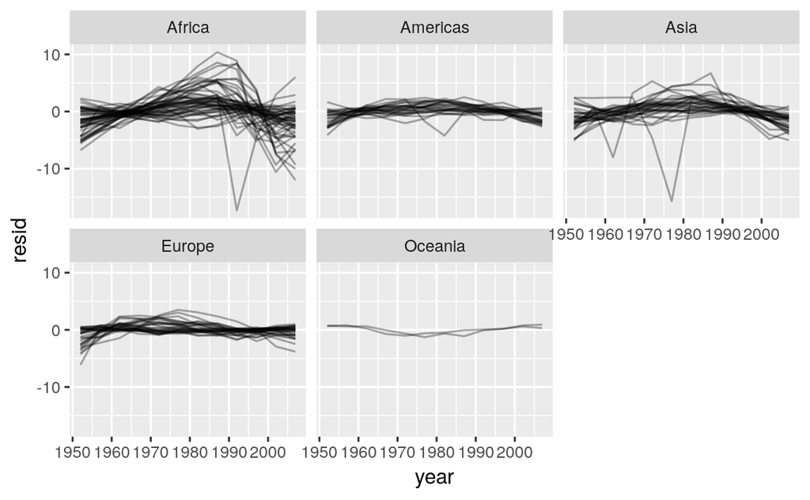

```r
resids %>%
  ggplot(aes(year, resid, group = country)) +
    geom_line(alpha = 1 / 3) +
    facet_wrap(~continent)
```

Parece que hay cierto patrón en los residuos que estamos perdiendonos con el modelo lineal

# Muchos Modelos- Clase 2

## Diagnóstico del modelo

vamos a utilizar la librería `broom` para calcular métricas de calidad del modelo. Este paquete forma parte del tidyverse, y nos va a permitir estandarizar el output de muchos modelos, lo que va a faciltar la comparación

Empezamos por usar `glance()` Para calcular algunas métricas típicas. Si lo aplicamos sobre un modelo, obtenemos un DF deuna fila y una columna para cada métrica

```r
glance(nz_mod)
```

```
#> # A tibble: 1 x 11
#>   r.squared adj.r.squared sigma statistic p.value    df logLik   AIC   BIC
#> *     <dbl>         <dbl> <dbl>     <dbl>   <dbl> <int>  <dbl> <dbl> <dbl>
#> 1     0.954         0.949 0.804      205. 5.41e-8     2  -13.3  32.6  34.1
#> # ... with 2 more variables: deviance <dbl>, df.residual <int>
```

Podemos usar `mutate()` y `unnest()` para crear un DF con una fila por país (modelo):

```r
by_country %>%
  mutate(glnc = map(model, glance)) %>%
  unnest(glnc)
```

```
#> # A tibble: 142 x 16
#>    country continent data  model resids r.squared adj.r.squared sigma
#>    <fct>   <fct>     <lis> <lis> <list>     <dbl>         <dbl> <dbl>
#>  1 Afghan… Asia      <tib… <S3:… <tibb…     0.948         0.942 1.22
#>  2 Albania Europe    <tib… <S3:… <tibb…     0.911         0.902 1.98
#>  3 Algeria Africa    <tib… <S3:… <tibb…     0.985         0.984 1.32
#>  4 Angola  Africa    <tib… <S3:… <tibb…     0.888         0.877 1.41
#>  5 Argent… Americas  <tib… <S3:… <tibb…     0.996         0.995 0.292
#>  6 Austra… Oceania   <tib… <S3:… <tibb…     0.980         0.978 0.621
#>  7 Austria Europe    <tib… <S3:… <tibb…     0.992         0.991 0.407
#>  8 Bahrain Asia      <tib… <S3:… <tibb…     0.967         0.963 1.64
#>  9 Bangla… Asia      <tib… <S3:… <tibb…     0.989         0.988 0.977
#> 10 Belgium Europe    <tib… <S3:… <tibb…     0.995         0.994 0.293
#> # ... with 132 more rows, and 8 more variables: statistic <dbl>,
#> #   p.value <dbl>, df <int>, logLik <dbl>, AIC <dbl>, BIC <dbl>,
#> #   deviance <dbl>, df.residual <int>
```

Si queremos sacarnos de encima las columnas de listas (`data`,`model`,`resids`), necesitamos agregar `.drop = TRUE`:

```r
glnc <- by_country %>%
  mutate(glnc = map(model, glance)) %>%
  unnest(glnc, .drop = TRUE)
glnc
```

```
#> # A tibble: 142 x 13
#>    country continent r.squared adj.r.squared sigma statistic  p.value    df
#>    <fct>   <fct>         <dbl>         <dbl> <dbl>     <dbl>    <dbl> <int>
#>  1 Afghan… Asia          0.948         0.942 1.22      181.  9.84e- 8     2
#>  2 Albania Europe        0.911         0.902 1.98      102.  1.46e- 6     2
#>  3 Algeria Africa        0.985         0.984 1.32      662.  1.81e-10     2
#>  4 Angola  Africa        0.888         0.877 1.41       79.1 4.59e- 6     2
#>  5 Argent… Americas      0.996         0.995 0.292    2246.  4.22e-13     2
#>  6 Austra… Oceania       0.980         0.978 0.621     481.  8.67e-10     2
#>  7 Austria Europe        0.992         0.991 0.407    1261.  7.44e-12     2
#>  8 Bahrain Asia          0.967         0.963 1.64      291.  1.02e- 8     2
#>  9 Bangla… Asia          0.989         0.988 0.977     930.  3.37e-11     2
#> 10 Belgium Europe        0.995         0.994 0.293    1822.  1.20e-12     2
#> # ... with 132 more rows, and 5 more variables: logLik <dbl>, AIC <dbl>,
#> #   BIC <dbl>, deviance <dbl>, df.residual <int>
```

Podemos empezar a buscar los peores modelos ordenando por $R^2$

```r
glnc %>%
  arrange(r.squared)
```

```
#> # A tibble: 142 x 13
#>    country continent r.squared adj.r.squared sigma statistic p.value    df
#>    <fct>   <fct>         <dbl>         <dbl> <dbl>     <dbl>   <dbl> <int>
#>  1 Rwanda  Africa       0.0172      -0.0811   6.56     0.175  0.685      2
#>  2 Botswa… Africa       0.0340      -0.0626   6.11     0.352  0.566      2
#>  3 Zimbab… Africa       0.0562      -0.0381   7.21     0.596  0.458      2
#>  4 Zambia  Africa       0.0598      -0.0342   4.53     0.636  0.444      2
#>  5 Swazil… Africa       0.0682      -0.0250   6.64     0.732  0.412      2
#>  6 Lesotho Africa       0.0849      -0.00666  5.93     0.927  0.358      2
#>  7 Cote d… Africa       0.283        0.212    3.93     3.95   0.0748     2
#>  8 South … Africa       0.312        0.244    4.74     4.54   0.0588     2
#>  9 Uganda  Africa       0.342        0.276    3.19     5.20   0.0457     2
#> 10 Congo,… Africa       0.348        0.283    2.43     5.34   0.0434     2
#> # ... with 132 more rows, and 5 more variables: logLik <dbl>, AIC <dbl>,
#> #   BIC <dbl>, deviance <dbl>, df.residual <int>
```

Podemos confirmar la intuición de que el modelo lineal no esta funcionando bien para Africa.

Graficamente:

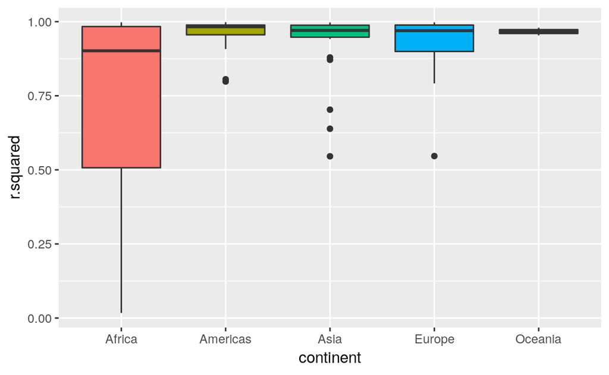

```r
glnc %>%
  ggplot(aes(continent, r.squared, fill = continent)) +
  geom_boxplot()+
  theme(legend.position = "none")
```

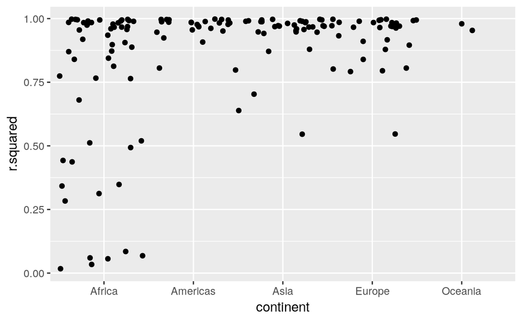

```r
glnc %>%
  ggplot(aes(continent, r.squared)) +
    geom_jitter(width = 0.5)
```

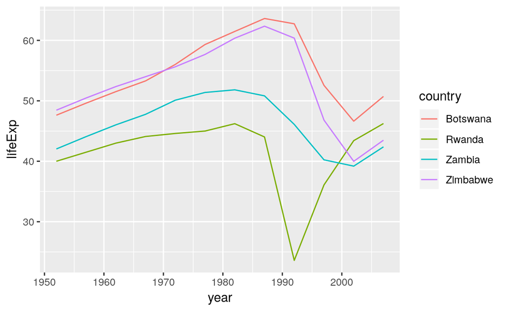

```r
#bad_fit <- filter(glnc, r.squared < 0.25)
bad_fit <- filter(glnc, rank(r.squared) < 5)

gapminder %>%
  semi_join(bad_fit, by = "country") %>%
  ggplot(aes(year, lifeExp, colour = country)) +
    geom_line()
```

Aquí vemos dos efectos principales: las tragedias de la epidemia de VIH / SIDA y el genocidio de Ruanda.

The broom package provides three general tools for turning models into tidy data frames:

## Tidy

El comando `tidy(model)` nos permite obtener la salida del modelo lineal de forma prolija.

En el caso particular de un modelo. El output tradicional se vería de esta forma

```r
nz_mod <- lm(lifeExp ~ year, data = nz)

summary(nz_mod)
```

```
#>
#> Call:
#> lm(formula = lifeExp ~ year, data = nz)
#>
#> Residuals:
#>      Min       1Q   Median       3Q      Max
#> -1.28745 -0.63700  0.06345  0.64442  0.91192
#>
#> Coefficients:
#>               Estimate Std. Error t value Pr(>|t|)
#> (Intercept) -307.69963   26.63039  -11.55 4.17e-07 ***
#> year           0.19282    0.01345   14.33 5.41e-08 ***
#> ---
#> Signif. codes:  0 '***' 0.001 '**' 0.01 '*' 0.05 '.' 0.1 ' ' 1
#>
#> Residual standard error: 0.8043 on 10 degrees of freedom
#> Multiple R-squared:  0.9536, Adjusted R-squared:  0.9489
#> F-statistic: 205.4 on 1 and 10 DF,  p-value: 5.407e-08
```

Tenemos para `intercept` y `year` un valor estimado, error estandar y el p-value para ver su significatividad.

A la mandera tidy

```r
tidy(nz_mod)
```

```
#> # A tibble: 2 x 5
#>   term        estimate std.error statistic      p.value
#>   <chr>          <dbl>     <dbl>     <dbl>        <dbl>
#> 1 (Intercept) -308.      26.6        -11.6 0.000000417
#> 2 year           0.193    0.0135      14.3 0.0000000541
```

De esta forma recuperamos las métricas que refieren a los coeficientes en un formato consistente. Esto es sumamente útil si queremos trabajar con varios modelos a la vez, o automatizar un pipline de trabajo con una salida de un modelo.

Por ejemplo, obtengamos estos valores para todas las rergesiones. Para ello, necesitamos mapear los modelos con la función tidy

```r
tdy <- by_country %>%
  mutate(tdy = map(model, tidy)) %>%
  unnest(tdy, .drop = TRUE)
tdy
```

```
#> # A tibble: 284 x 7
#>    country     continent term         estimate std.error statistic  p.value
#>    <fct>       <fct>     <chr>           <dbl>     <dbl>     <dbl>    <dbl>
#>  1 Afghanistan Asia      (Intercept)  -508.     40.5        -12.5  1.93e- 7
#>  2 Afghanistan Asia      year            0.275   0.0205      13.5  9.84e- 8
#>  3 Albania     Europe    (Intercept)  -594.     65.7         -9.05 3.94e- 6
#>  4 Albania     Europe    year            0.335   0.0332      10.1  1.46e- 6
#>  5 Algeria     Africa    (Intercept) -1068.     43.8        -24.4  3.07e-10
#>  6 Algeria     Africa    year            0.569   0.0221      25.7  1.81e-10
#>  7 Angola      Africa    (Intercept)  -377.     46.6         -8.08 1.08e- 5
#>  8 Angola      Africa    year            0.209   0.0235       8.90 4.59e- 6
#>  9 Argentina   Americas  (Intercept)  -390.      9.68       -40.3  2.14e-12
#> 10 Argentina   Americas  year            0.232   0.00489     47.4  4.22e-13
#> # ... with 274 more rows
```

Noten que para cada país ahora tenemos dos filas, una para cada coeficiente del modelo.

Con esta tabla, ahora podríamos graficar los coeficientes del modelo.

Para un sólo modelo (nz_mod):

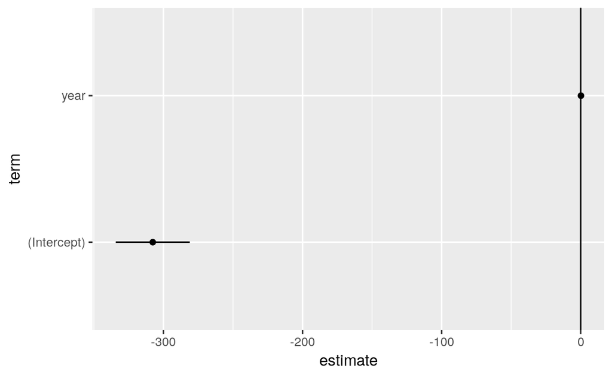

```r
tidy(nz_mod) %>% mutate(low = estimate - std.error,
                          high = estimate + std.error) %>%
ggplot(., aes(estimate, term, xmin = low, xmax = high, height = 0)) +
     geom_point() +
     geom_vline(xintercept = 0) +
     geom_errorbarh()
```

En este gráfico tenemos graficado cada uno de los parámetros del modelo, con +-1 desvío estandar. si quisieramos comparar todos los modelos.

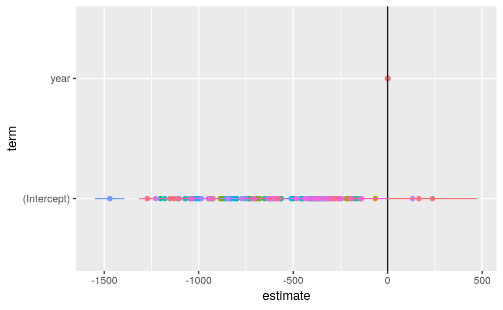

```r
tdy %>% mutate(low = estimate - std.error,
                          high = estimate + std.error) %>%
ggplot(., aes(estimate, term, xmin = low, xmax = high, height = 0, color = country)) +
     geom_point() +
     geom_vline(xintercept = 0) +
     geom_errorbarh()+
  theme(legend.position = "none")
```

¿cómo interpretan estos coeficientes? ¿qué representa el intercepto de cada modelo?

## augment

la función `lm()` también tiene una serie de gráficos para evaluar la calidad del modelo que pueden ser muy útiles para encontrar si un modelo esta mal calibrado.

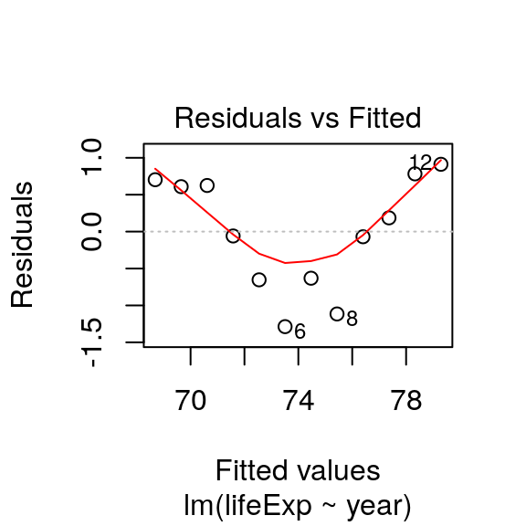

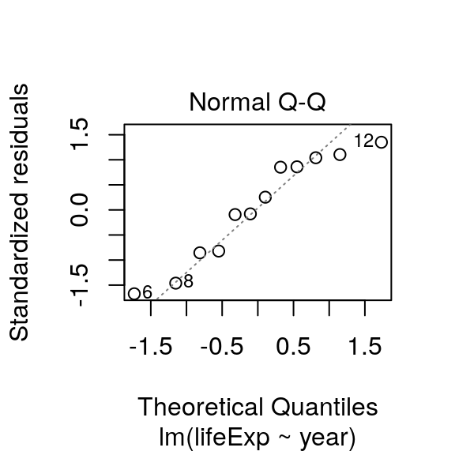

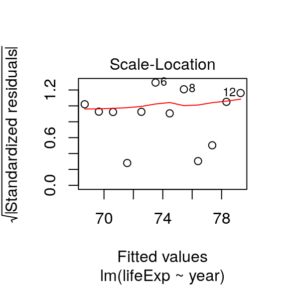

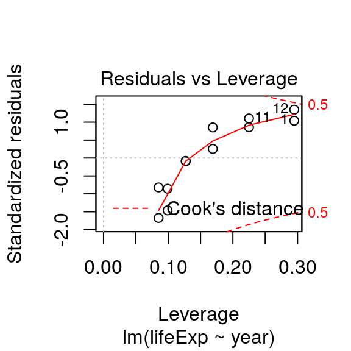

```r
plot(nz_mod)
```

Estos gráficos son:

- Residuos versus el modelo ajustado: El objetivo es que no veamos una estructura clara. Si así la hubiera, esto implicaría que hay una parte **sistemática** del fenómeno que se esta perdiendo.
- Normal QQ plot: sirve para ver si los datos siguen una distribución teórica, en este caso, la $\sim N(0,1)$. Los residuos estandarizados, si el modelo esta bien definido, deberían seguir esta distribución
- Scale-location plot: Similar al primer gráfico, pero utilizando la raiz cuadrada de los residuos estandarizados. De la misma forma que el anterior, buscamos que no haya una estructura en los residuos.
- scale vs leverage: El leverage mide cuan influyentes son los puntos en el modelo. Si en este gráfico algunas observacione aparecen muy separadas, con mucho leverage y residuo, significa que cambian mucho al modelo.

La función `augment(model, data)` nos permite recuperar la información necesaria para estos gráficos de forma sistemática.

```r
au <- augment(nz_mod,nz)
au
```

```
#> # A tibble: 12 x 13
#>    country continent  year lifeExp    pop gdpPercap .fitted .se.fit  .resid
#>  * <fct>   <fct>     <int>   <dbl>  <int>     <dbl>   <dbl>   <dbl>   <dbl>
#>  1 New Ze… Oceania    1952    69.4 1.99e6    10557.    68.7   0.437  0.703
#>  2 New Ze… Oceania    1957    70.3 2.23e6    12247.    69.7   0.381  0.609
#>  3 New Ze… Oceania    1962    71.2 2.49e6    13176.    70.6   0.331  0.625
#>  4 New Ze… Oceania    1967    71.5 2.73e6    14464.    71.6   0.287 -0.0592
#>  5 New Ze… Oceania    1972    71.9 2.93e6    16046.    72.5   0.253 -0.653
#>  6 New Ze… Oceania    1977    72.2 3.16e6    16234.    73.5   0.235 -1.29
#>  7 New Ze… Oceania    1982    73.8 3.21e6    17632.    74.5   0.235 -0.632
#>  8 New Ze… Oceania    1987    74.3 3.32e6    19007.    75.4   0.253 -1.12
#>  9 New Ze… Oceania    1992    76.3 3.44e6    18363.    76.4   0.287 -0.0698
#> 10 New Ze… Oceania    1997    77.6 3.68e6    21050.    77.4   0.331  0.186
#> 11 New Ze… Oceania    2002    79.1 3.91e6    23190.    78.3   0.381  0.782
#> 12 New Ze… Oceania    2007    80.2 4.12e6    25185.    79.3   0.437  0.912
#> # ... with 4 more variables: .hat <dbl>, .sigma <dbl>, .cooksd <dbl>,
#> #   .std.resid <dbl>
```

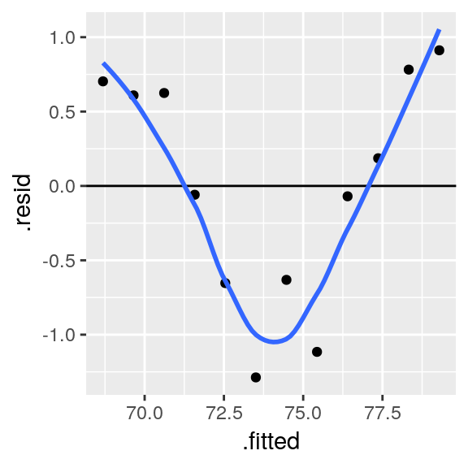

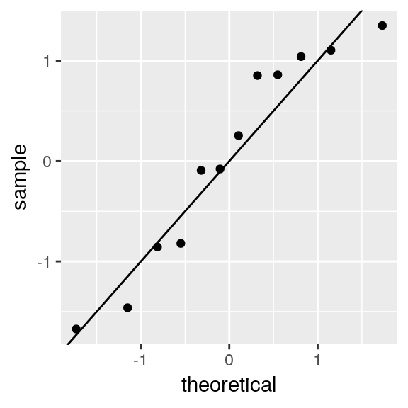

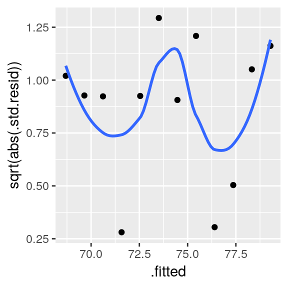

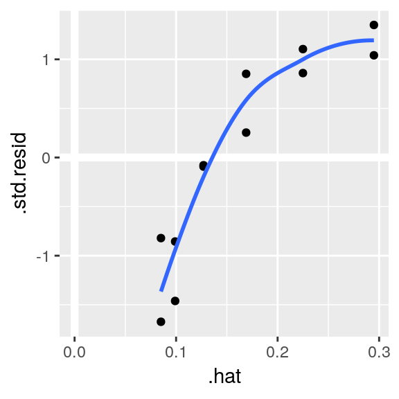

```r
ggplot(au, aes(.fitted, .resid)) +
  geom_point()+
  geom_hline(yintercept = 0) +
  geom_smooth(se = FALSE)
ggplot(au, aes(sample= .std.resid))+
  stat_qq()+
  geom_abline()

ggplot(au, aes(.fitted, sqrt(abs(.std.resid))))+
  geom_point()+
  geom_smooth(se = FALSE)
ggplot(au, aes(.hat, .std.resid)) +
  geom_vline(size = 2, colour = "white", xintercept = 0) +
  geom_hline(size = 2, colour = "white", yintercept = 0) +
  geom_point() + geom_smooth(se = FALSE)
```

De la misma forma que con las otras funciones, podemos utilizar `map2(model, data, augment)` para calcular esto para todos nuestros modelos en simultaneo.

```r
augment <- by_country %>%
  mutate(augment = map2( model,data,augment)) %>%
  unnest(augment, .drop = TRUE)
augment
```

```
#> # A tibble: 1,704 x 13
#>    country continent  year lifeExp    pop gdpPercap .fitted .se.fit  .resid
#>    <fct>   <fct>     <int>   <dbl>  <int>     <dbl>   <dbl>   <dbl>   <dbl>
#>  1 Afghan… Asia       1952    28.8 8.43e6      779.    29.9   0.664 -1.11
#>  2 Afghan… Asia       1957    30.3 9.24e6      821.    31.3   0.580 -0.952
#>  3 Afghan… Asia       1962    32.0 1.03e7      853.    32.7   0.503 -0.664
#>  4 Afghan… Asia       1967    34.0 1.15e7      836.    34.0   0.436 -0.0172
#>  5 Afghan… Asia       1972    36.1 1.31e7      740.    35.4   0.385  0.674
#>  6 Afghan… Asia       1977    38.4 1.49e7      786.    36.8   0.357  1.65
#>  7 Afghan… Asia       1982    39.9 1.29e7      978.    38.2   0.357  1.69
#>  8 Afghan… Asia       1987    40.8 1.39e7      852.    39.5   0.385  1.28
#>  9 Afghan… Asia       1992    41.7 1.63e7      649.    40.9   0.436  0.754
#> 10 Afghan… Asia       1997    41.8 2.22e7      635.    42.3   0.503 -0.534
#> # ... with 1,694 more rows, and 4 more variables: .hat <dbl>,
#> #   .sigma <dbl>, .cooksd <dbl>, .std.resid <dbl>
```

[^1]: Estas notas estan basadas en Hadley Wickham and Garrett Grolemund. 2017. R for Data Science Import, Tidy, Transform, Visualize, and Model Data (1st ed.). O’Reilly Media, Inc. http://r4ds.had.co.nz.